# Day 6: Advanced EDA & Patterns — In-Class Activity (Solutions)

World Happiness Report 2023

Instructor

## Setup: Load and Prepare the Data

Identical to the student version.

```r
whr_url  <- "https://raw.githubusercontent.com/mgelman/data/master/whr2023.csv"
whr_data <- read_csv(whr_url)

whr_data <- whr_data %>%
  rename(
    happiness                    = `Happiness score`,
    Logged_GDP_per_capita        = `Logged GDP per capita`,
    Social_support               = `Social support`,
    Healthy_life_expectancy      = `Healthy life expectancy`,
    Freedom_to_make_life_choices = `Freedom to make life choices`,
    Perceptions_of_corruption    = `Perceptions of corruption`,
    Regional_indicator           = `Regional indicator`,
    Country_name                 = `Country name`
  ) %>%
  na.omit()

whr_data <- whr_data %>%
  mutate(GDP_per_capita_raw = exp(Logged_GDP_per_capita))

whr_data <- whr_data %>%
  mutate(happiness_bin = cut(happiness,
                             breaks = c(0, 4.5, 6.5, Inf),
                             labels = c("Low", "Medium", "High"),
                             right  = FALSE))

dim(whr_data)
```

```
## [1] 136  23
```

## Part 1: Money and Happiness

### Task 1.1: Raw GDP per capita vs. happiness

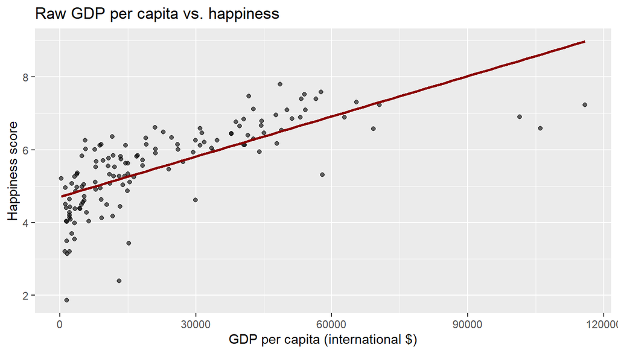

```r
ggplot(whr_data, aes(x = GDP_per_capita_raw, y = happiness)) +
  geom_point(alpha = 0.6) +
  geom_smooth(method = "lm", se = FALSE, color = "darkred") +
  labs(title = "Raw GDP per capita vs. happiness",
       x = "GDP per capita (international $)", y = "Happiness score")
```

The points bow away from the line: steep on the left, then flattening. The fitted line sits *below* the data in the middle of the range and *above* it at both ends — the signature of fitting a straight line to a curve.

### Task 1.2: Logged GDP per capita vs. happiness

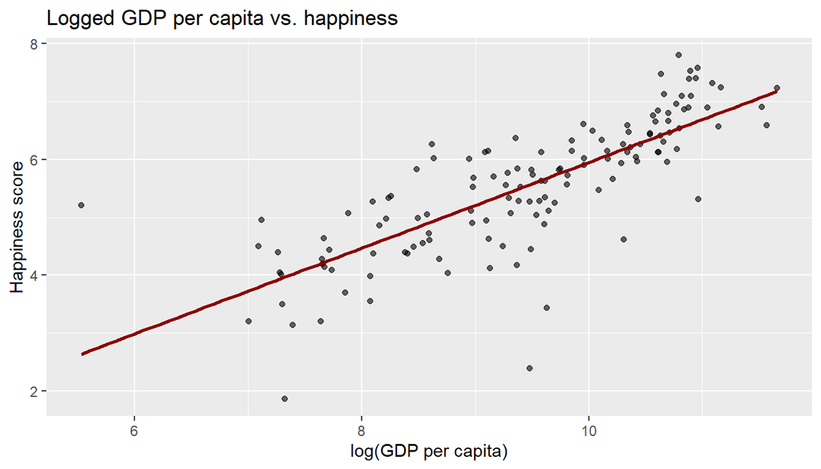

```r
ggplot(whr_data, aes(x = Logged_GDP_per_capita, y = happiness)) +
  geom_point(alpha = 0.6) +
  geom_smooth(method = "lm", se = FALSE, color = "darkred") +
  labs(title = "Logged GDP per capita vs. happiness",
       x = "log(GDP per capita)", y = "Happiness score")
```

```r
round(c(raw    = summary(lm(happiness ~ GDP_per_capita_raw,    whr_data))$r.squared,
        logged = summary(lm(happiness ~ Logged_GDP_per_capita, whr_data))$r.squared), 3)
```

```
##    raw logged
##  0.521  0.614
```

```r
round(range(whr_data$GDP_per_capita_raw))
```

```
## [1]    251 115844
```

*Which version is better described by a straight line? What does that tell you about how income relates to happiness — does an extra $1,000 mean the same thing to a rich country as to a poor one?*

The **logged** version. R-squared rises from **0.52** to **0.61**, and more importantly the scatter around the line stops being systematic — the bow is gone.

The economics: a straight line against a log axis means happiness tracks the **percent** change in income, not the dollar change. An extra $1,000 is a large percent change for a country at $1,500 per capita and a rounding error for one at $60,000, so it buys far more happiness in the first case. That is diminishing returns, and taking logs is how we let a straight line express it.

So: **no**, an extra $1,000 does not mean the same thing to both. Raw GDP per capita here runs from about **$251** to **$115,844**, a 460-fold spread. A variable with that range is almost always better handled in logs.

### Task 1.3: Does the relationship hold everywhere?

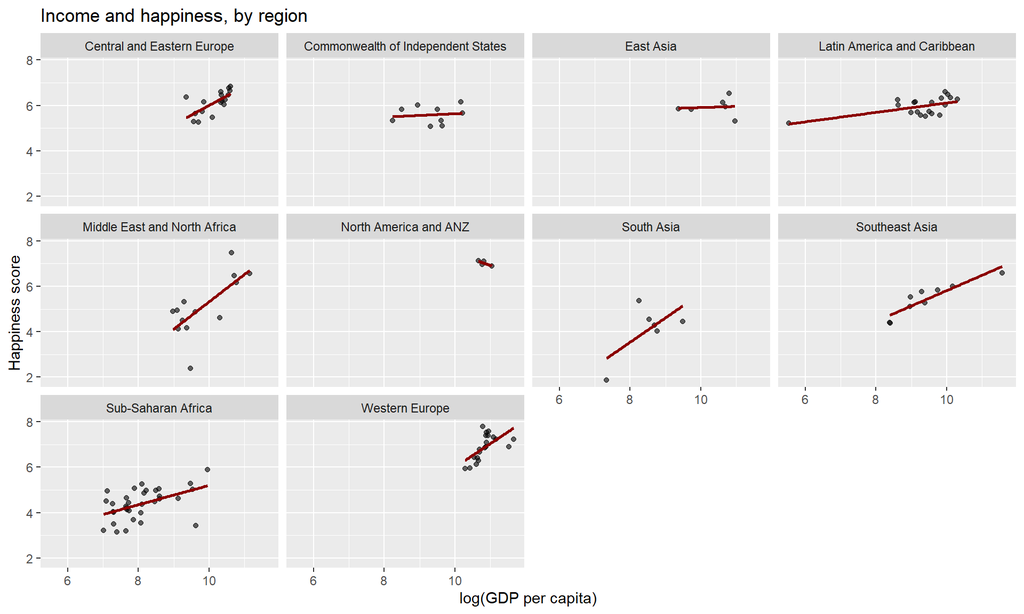

```r
ggplot(whr_data, aes(x = Logged_GDP_per_capita, y = happiness)) +
  geom_point(alpha = 0.6) +
  geom_smooth(method = "lm", se = FALSE, color = "darkred") +
  facet_wrap(~ Regional_indicator) +
  labs(title = "Income and happiness, by region",
       x = "log(GDP per capita)", y = "Happiness score")
```

```r
whr_data %>%
  group_by(Regional_indicator) %>%
  summarize(n     = n(),
            slope = round(coef(lm(happiness ~ Logged_GDP_per_capita,
                                  pick(everything())))[2], 2),
            .groups = "drop") %>%
  arrange(desc(n))
```

```
## # A tibble: 10 × 3
##    Regional_indicator                     n slope
##    <chr>                              <int> <dbl>
##  1 Sub-Saharan Africa                    33  0.43
##  2 Western Europe                        20  1.03
##  3 Latin America and Caribbean           19  0.21
##  4 Central and Eastern Europe            17  0.84
##  5 Middle East and North Africa          13  1.2
##  6 Commonwealth of Independent States     9  0.07
##  7 Southeast Asia                         9  0.67
##  8 East Asia                              6  0.05
##  9 South Asia                             6  1.07
## 10 North America and ANZ                  4 -0.53
```

*Pick two regions whose slopes look different and describe the difference.*

The strongest single pair is **Western Europe** (n = 20, slope **1.03**) against **Latin America and Caribbean** (n = 19, slope **0.21**).

One unit of log GDP is a **2.72x** increase in income. So within Western Europe, a country with roughly triple the income of another scores about **a full point** higher on happiness. Within Latin America the same income multiple buys about **0.2 points** — a fifth as much. Income tells you a great deal about which Western European country you are looking at, and almost nothing about which Latin American one.

This is the best pair to pick precisely because of the caution in the task: **n = 20 and n = 19 are nearly identical**, so the gap cannot be explained away as one region having fewer countries.

The substance behind it is worth a moment. Latin America averages **5.97** happiness at mean log GDP **9.29**; Western Europe averages **6.89** at **10.86**. Latin America is far poorer but nothing like proportionally less happy — it sits *above* what its income predicts, and within the region income stops being informative. This is a well-known pattern in the happiness literature, usually attributed to family and social ties, and Task 1.4 gives a hint of the mechanism: `Social_support` correlates with happiness (0.84) even more strongly than income does (0.78).

Other defensible pairs, both with usable sample sizes:

- **Middle East and North Africa** (n = 13, **1.20**) vs. **Commonwealth of Independent States** (n = 9, **0.07**) — the widest gap among mid-sized regions.
- **Western Europe** (n = 20, **1.03**) vs. **Sub-Saharan Africa** (n = 33, **0.43**) — the two largest well-populated panels.

A pair to push back on: **South Asia** (**1.07**) vs. **East Asia** (**0.05**) looks like the most dramatic contrast on the page, but **both rest on 6 countries**. The slopes may be real; this data cannot show it.

**The trap, and why the warning is in the task.** **North America and ANZ** has a slope of **-0.53** — negative. It also has **n = 4**. Four points, one of which (the United States) is rich and comparatively unhappy, are enough to tilt a line downward. Nobody should report “in North America, money makes you miserable” off four observations.

Ask what you would need before believing that slope: more countries, a confidence band, a robustness check. A fitted line always exists, whether or not there is anything behind it.

### Task 1.4: Correlation heatmap

```r
cor_vars <- c("happiness", "Logged_GDP_per_capita", "Social_support",
              "Healthy_life_expectancy", "Freedom_to_make_life_choices",
              "Perceptions_of_corruption")

cor_matrix <- whr_data %>% select(all_of(cor_vars)) %>% cor()
round(cor_matrix, 2)
```

```
##                              happiness Logged_GDP_per_capita Social_support
## happiness                         1.00                  0.78           0.84
## Logged_GDP_per_capita             0.78                  1.00           0.74
## Social_support                    0.84                  0.74           1.00
## Healthy_life_expectancy           0.75                  0.84           0.73
## Freedom_to_make_life_choices      0.66                  0.45           0.55
## Perceptions_of_corruption        -0.47                 -0.44          -0.28
##                              Healthy_life_expectancy
## happiness                                       0.75
## Logged_GDP_per_capita                           0.84
## Social_support                                  0.73
## Healthy_life_expectancy                         1.00
## Freedom_to_make_life_choices                    0.42
## Perceptions_of_corruption                      -0.40
##                              Freedom_to_make_life_choices
## happiness                                            0.66
## Logged_GDP_per_capita                                0.45
## Social_support                                       0.55
## Healthy_life_expectancy                              0.42
## Freedom_to_make_life_choices                         1.00
## Perceptions_of_corruption                           -0.38
##                              Perceptions_of_corruption
## happiness                                        -0.47
## Logged_GDP_per_capita                            -0.44
## Social_support                                   -0.28
## Healthy_life_expectancy                          -0.40
## Freedom_to_make_life_choices                     -0.38
## Perceptions_of_corruption                         1.00
```

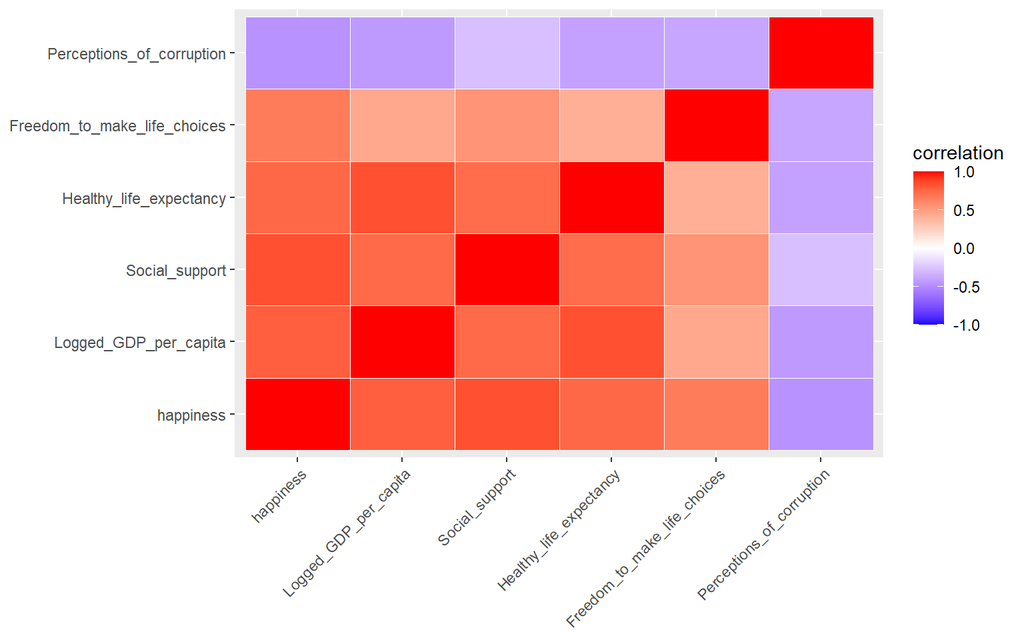

```r
cor_long <- as.data.frame(cor_matrix) %>%
  mutate(var1 = rownames(cor_matrix)) %>%
  pivot_longer(-var1, names_to = "var2", values_to = "correlation") %>%
  mutate(var1 = factor(var1, levels = cor_vars),
         var2 = factor(var2, levels = cor_vars))

ggplot(cor_long, aes(x = var1, y = var2, fill = correlation)) +
  geom_tile(color = "white") +
  scale_fill_gradient2(low = "blue", mid = "white", high = "red",
                       midpoint = 0, limits = c(-1, 1)) +
  labs(x = NULL, y = NULL) +
  theme(axis.text.x = element_text(angle = 45, hjust = 1))
```

*Which variable is the odd one out — correlating in the opposite direction from everything else? Does the sign make sense to you?*

**`Perceptions_of_corruption`** — the only blue row and column on the map. It correlates **negatively with everything**: **-0.47** with happiness, **-0.44** with logged GDP, **-0.40** with life expectancy, **-0.38** with freedom, **-0.28** with social support.

The sign makes sense once you read the variable name carefully. It measures **perceived corruption**, so a high score is a *bad* thing, while every other variable here is coded so that high is *good*. Countries where people believe government and business are corrupt report lower happiness, lower income and shorter lives. Nothing paradoxical is happening — the variable simply points the other way.

Worth a minute of discussion: this is the same trap as an `unemployment_rate` or `infant_mortality` column sitting in a table of otherwise-good outcomes. **Check which direction a variable is coded before interpreting its sign.**

Note too that this is the first negative correlation to appear on one of these heatmaps — the `Credit` map in class was entirely red, so the blue half of `scale_fill_gradient2()` finally does some work.

## Part 2: Which Countries Don’t Fit?

### Task 2.1: Box plot of happiness

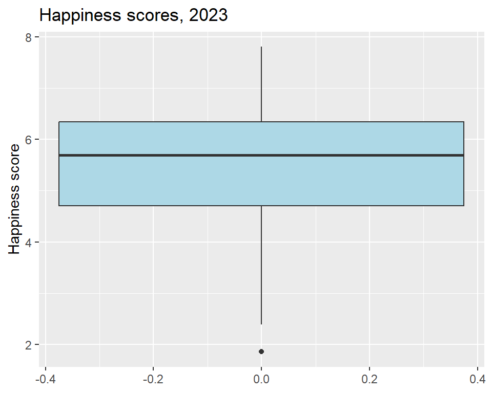

```r
ggplot(whr_data, aes(y = happiness)) +
  geom_boxplot(fill = "lightblue") +
  labs(title = "Happiness scores, 2023", y = "Happiness score")
```

*How many points fall outside the whiskers?*

**Exactly one**, at the bottom. Students should count dots here, not compute — Task 2.2 is where they check the number.

### Task 2.2: The IQR rule

```r
Q1      <- quantile(whr_data$happiness, 0.25)
Q3      <- quantile(whr_data$happiness, 0.75)
IQR_val <- Q3 - Q1

round(c(Q1 = Q1, Q3 = Q3, IQR = IQR_val,
        lower_fence = Q1 - 1.5 * IQR_val,
        upper_fence = Q3 + 1.5 * IQR_val), 2)
```

```
##          Q1.25%          Q3.75%         IQR.75% lower_fence.25% upper_fence.75%
##            4.70            6.34            1.64            2.24            8.80
```

```r
whr_data %>%
  filter(happiness < Q1 - 1.5 * IQR_val | happiness > Q3 + 1.5 * IQR_val) %>%
  select(Country_name, Regional_indicator, happiness)
```

```
## # A tibble: 1 × 3
##   Country_name Regional_indicator happiness
##   <chr>        <chr>                  <dbl>
## 1 Afghanistan  South Asia              1.86
```

One country: **Afghanistan**, at **1.859**. The fences are **2.24** and **8.80**; the highest score in the data is Finland at 7.80, so the upper fence is out of reach and nothing is flagged at the top.

### Task 2.3: The z-score rule

```r
whr_z <- whr_data %>% mutate(happiness_z = as.numeric(scale(happiness)))

whr_z %>%
  filter(abs(happiness_z) > 1.5) %>%
  arrange(happiness_z) %>%
  select(Country_name, Regional_indicator, happiness, happiness_z) %>%
  mutate(happiness_z = round(happiness_z, 2))
```

```
## # A tibble: 16 × 4
##    Country_name     Regional_indicator           happiness happiness_z
##    <chr>            <chr>                            <dbl>       <dbl>
##  1 Afghanistan      South Asia                        1.86       -3.22
##  2 Lebanon          Middle East and North Africa      2.39       -2.76
##  3 Sierra Leone     Sub-Saharan Africa                3.14       -2.11
##  4 Zimbabwe         Sub-Saharan Africa                3.20       -2.05
##  5 Congo (Kinshasa) Sub-Saharan Africa                3.21       -2.05
##  6 Botswana         Sub-Saharan Africa                3.44       -1.85
##  7 Malawi           Sub-Saharan Africa                3.50       -1.79
##  8 Comoros          Sub-Saharan Africa                3.54       -1.75
##  9 Tanzania         Sub-Saharan Africa                3.69       -1.62
## 10 Norway           Western Europe                    7.32        1.55
## 11 Sweden           Western Europe                    7.40        1.62
## 12 Netherlands      Western Europe                    7.40        1.63
## 13 Israel           Middle East and North Africa      7.47        1.69
## 14 Iceland          Western Europe                    7.53        1.74
## 15 Denmark          Western Europe                    7.59        1.79
## 16 Finland          Western Europe                    7.80        1.98
```

```r
c(iqr_rule   = 1,
  z_over_1.5 = sum(abs(whr_z$happiness_z) > 1.5),
  z_over_2.0 = sum(abs(whr_z$happiness_z) > 2.0))
```

```
##   iqr_rule z_over_1.5 z_over_2.0
##          1         16          5
```

*Which ones does the z-score rule add? What happens if you use the usual 2.0 instead of 1.5?*

At **|z| > 1.5** the rule flags **16** countries — Afghanistan plus eight more on the unhappy side (Lebanon, Sierra Leone, Zimbabwe, Congo (Kinshasa), Botswana, Malawi, Comoros, Tanzania) and seven on the happy side (Norway, Sweden, Netherlands, Israel, Iceland, Denmark, Finland).

At **|z| > 2.0** it drops to **5**, all at the bottom: Afghanistan, Lebanon, Sierra Leone, Zimbabwe, Congo (Kinshasa).

**Why the rules disagree so much here** — and this is the part worth drawing out, because the reason is *not* the same as the `Income` example from class:

```r
mu  <- mean(whr_data$happiness)
sdv <- sd(whr_data$happiness)

round(c(mean = mu, sd = sdv,
        lower_fence_in_z = (Q1 - 1.5 * IQR_val - mu) / sdv,
        upper_fence_in_z = (Q3 + 1.5 * IQR_val - mu) / sdv), 2)
```

```
##                 mean                   sd lower_fence_in_z.25%
##                 5.54                 1.14                -2.89
## upper_fence_in_z.75%
##                 2.85
```

The IQR fences sit about **2.9 standard deviations** from the center, so on this data the IQR rule is roughly equivalent to “|z| > 2.9” — a far stricter bar than the 1.5 the task asked for. The rules disagree because we chose a loose threshold, not because the data is skewed.

That contrast is deliberate. In class, `Income` was badly right-skewed and the two rules diverged because the outliers inflated the SD they were measured against. Happiness is close to symmetric, so here **the same two rules agree in shape and differ only in strictness**. Same tools, different reason.

### Task 2.4: Outlier ≠ error

*Are any of these data errors? If not — what are they, and what would be lost by dropping them?*

**None of them are errors.** Every country on the list is a real place with a real survey behind it, and the values are what you would guess from the news: Afghanistan (1.86) and Lebanon (2.39) were both in acute crisis during the survey window, and the Nordic countries at the top have led this index for a decade.

What dropping them would cost:

- **The range itself.** Afghanistan and Finland are the two ends of the scale. Delete them and you have shrunk the very thing you are trying to explain.
- **The most informative cases.** If the question is what makes countries unhappy, the unhappiest country is the single most useful observation available.
- **Any honest description of the world.** These are not measurement glitches; they are the finding.

A strong answer distinguishes *implausible* from *extreme*. A happiness score of 47, or of -3, would be an error — the scale runs 0 to 10. A score of 1.86 is extreme but entirely possible, so it stays and you investigate it.

## Part 3: Transformation and Categories

### Task 3.1: What the log did

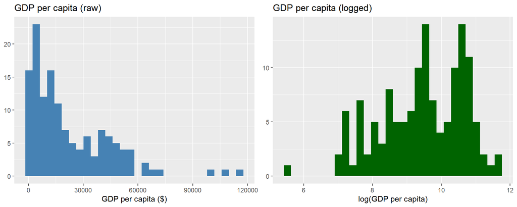

```r
raw_hist <- ggplot(whr_data, aes(x = GDP_per_capita_raw)) +
  geom_histogram(bins = 30, fill = "steelblue") +
  labs(title = "GDP per capita (raw)", x = "GDP per capita ($)", y = NULL)

log_hist <- ggplot(whr_data, aes(x = Logged_GDP_per_capita)) +
  geom_histogram(bins = 30, fill = "darkgreen") +
  labs(title = "GDP per capita (logged)", x = "log(GDP per capita)", y = NULL)

grid.arrange(raw_hist, log_hist, ncol = 2)
```

*Connect this back to Task 1.2 — why did the logged scatter plot look more linear?*

The raw histogram piles against the left wall with a long right tail: most countries are poor, a handful are very rich. The logged histogram is roughly symmetric.

In one sentence: *the log fixed the scatter plot by fixing the distribution underneath it.*

### Task 3.2: Happiness levels by region

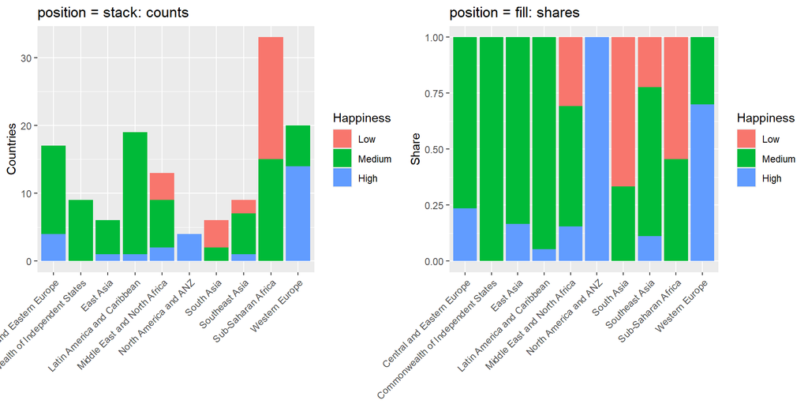

```r
counts <- ggplot(whr_data, aes(x = Regional_indicator, fill = happiness_bin)) +
  geom_bar(position = "stack") +
  labs(title = "position = stack: counts", x = NULL, y = "Countries",
       fill = "Happiness") +
  theme(axis.text.x = element_text(angle = 45, hjust = 1))

shares <- ggplot(whr_data, aes(x = Regional_indicator, fill = happiness_bin)) +
  geom_bar(position = "fill") +
  labs(title = "position = fill: shares", x = NULL, y = "Share",
       fill = "Happiness") +
  theme(axis.text.x = element_text(angle = 45, hjust = 1))

grid.arrange(counts, shares, ncol = 2)
```

```r
table(whr_data$Regional_indicator, whr_data$happiness_bin)
```

```
##
##                                      Low Medium High
##   Central and Eastern Europe           0     13    4
##   Commonwealth of Independent States   0      9    0
##   East Asia                            0      5    1
##   Latin America and Caribbean          0     18    1
##   Middle East and North Africa         4      7    2
##   North America and ANZ                0      0    4
##   South Asia                           4      2    0
##   Southeast Asia                       2      6    1
##   Sub-Saharan Africa                  18     15    0
##   Western Europe                       0      6   14
```

*Which of the two answers “where are unhappy countries concentrated?” and which answers “what share of this region is unhappy?” Do they point to different regions?*

- **`position = "stack"`** answers the *concentration* question, because bar height is a count. **Sub-Saharan Africa** dominates: 18 of the 28 “Low” countries in the whole dataset are there.
- **`position = "fill"`** answers the *share* question, because every bar is normalized to 1. Here **South Asia** stands out — 4 of its 6 countries are “Low”, a **67%** share, against Sub-Saharan Africa’s 18 of 33, or **55%**.

**Yes, they point to different regions**, and that is the whole exercise. If you are allocating a fixed budget by need, the count plot tells you where the most affected countries are. If you are asking which region is worst off *as a region*, the share plot says South Asia. Neither is wrong — they answer different questions, and a chart that silently picks one for you has made an argument on your behalf.

Worth saying out loud: South Asia’s 67% rests on **6 countries**. Same caution as Task 1.3.

## Wrap-up & Discussion

**1. If you had to report one list of “unusual countries,” which would you use, and what would you say about it?**

Either rule is defensible provided the choice is stated. The honest answer names a threshold *and* its consequence: “|z| > 2, which gives 5 countries, all in crisis” is a claim someone else can check. “The outliers” is not.

Because happiness is near-symmetric here, the choice of *rule* matters far less than the choice of *cutoff* — the two rules sit about 2.9 SD apart only because we set 1.5 by hand. If you spotted that in Task 2.3, say so here.

**2. When is faceting worth it, and when does it just give you ten noisy plots?**

Worth it when you expect the relationship to *differ* by group and each panel has enough data to show it. Not worth it when the panels get thin — ours ranged from 33 countries to 4, and the 4-country panel produced a negative slope that means nothing. A usable rule of thumb: if you would not fit a line to a panel on its own, do not let `facet_wrap()` fit one for you.

**3. Pick the strongest correlation and give one reason it might not mean what it appears to mean.**

The strongest is **happiness and social support, at 0.84**. Reasons it may mislead:

- **Reverse causation** — happier people may build and keep stronger networks.
- **Both are survey answers from the same respondents on the same day.** Someone in a bad mood answers both questions more negatively, which manufactures correlation out of the measurement process alone.
- **Confounding** — rich, stable, peaceful countries score high on both.

The second is the sharpest and the one students usually miss: two variables measured by the same instrument on the same people are correlated partly *by construction*.

**4. `na.omit()` silently dropped one country. How would you want to be told if it had been 30?**

The dropped country is **State of Palestine**, missing `Healthy life expectancy`. Good answers:

- Count rows before and after and print the difference — one line, every time.
- Print *which* rows went and *which* column was missing, so you can see whether the missingness is random or systematic.
- Recognize the real danger: if 30 countries dropped, they would almost certainly be the poorest and least-surveyed ones, so everything computed afterward would describe a systematically rosier world. `na.omit()` would not warn you.

The habit worth teaching: **any line that changes your row count should say so.**